# Covid Project

Benny, Nathan, Athiwat, Rami

5/20/2021

## Introduction

We chose to do our topic on Covid just because of how much it has impacted our lives this past year. We wanted to research how severe this disease actually is, at many stages throughout this time. As well as the future of Covid with people now getting vaccinated and how the vaccine will affect us. We acquired multiple data sets from deaths across the world, vaccinations in the US, and cases in Washington. Here are our 3 data sources of data for the project: [Vaccinations in U.S.](https://www.kaggle.com/paultimothymooney/usa-covid19-vaccinations), [International Covid Deaths](https://ourworldindata.org/coronavirus-source-data), [COVID-19 in WA](https://www.doh.wa.gov/Emergencies/COVID19/DataDashboard).

## Summary Information

For the summary information section, we decided to investigate toward the US population in particular. Therefore we use the data set from the [ourworldindata](https://ourworldindata.org/coronavirus-source-data) data source containing data about Covid-19. The first piece of information that we gain was that the total number of cases in the united states is currently 32707640 cases. Where unfortunately 581754 lives have passed away due to this pandemic. Even though not everyone was tested yet, so far they have done 421912895 tests. This resulted in a positive rate of covid from testing of 7.7 percents. Despite all the setback from this bad virus, the amount of people who got vaccination was 244778347 people within the United States.

## Summary Table

| County | Confirmed Cases | Ages 0-19 | Ages 20-34 | Ages 35-49 | Ages 50-64 | Ages 65-79 | Ages 80+ |
| --- | --- | --- | --- | --- | --- | --- | --- |
| King County | 99189 | 17269 | 33323 | 24838 | 17670 | 6909 | 3044 |
| Pierce County | 46018 | 8521 | 15676 | 12035 | 8715 | 3482 | 1416 |
| Spokane County | 39510 | 6813 | 12560 | 9350 | 7792 | 3684 | 1450 |
| Snohomish County | 34440 | 6113 | 10406 | 9211 | 6710 | 2664 | 1184 |
| Yakima County | 26317 | 5035 | 8994 | 7250 | 5174 | 2267 | 800 |
| Clark County | 21813 | 3713 | 6616 | 5916 | 4149 | 1768 | 640 |
| Benton County | 16113 | 3028 | 5048 | 4025 | 2866 | 1250 | 477 |
| Franklin County | 11952 | 2552 | 3661 | 3173 | 1992 | 699 | 154 |
| Whatcom County | 8197 | 1969 | 2481 | 1771 | 1384 | 628 | 276 |
| Thurston County | 8070 | 1528 | 2836 | 2086 | 1613 | 710 | 277 |

## Chart 1: Common Vaccine Days

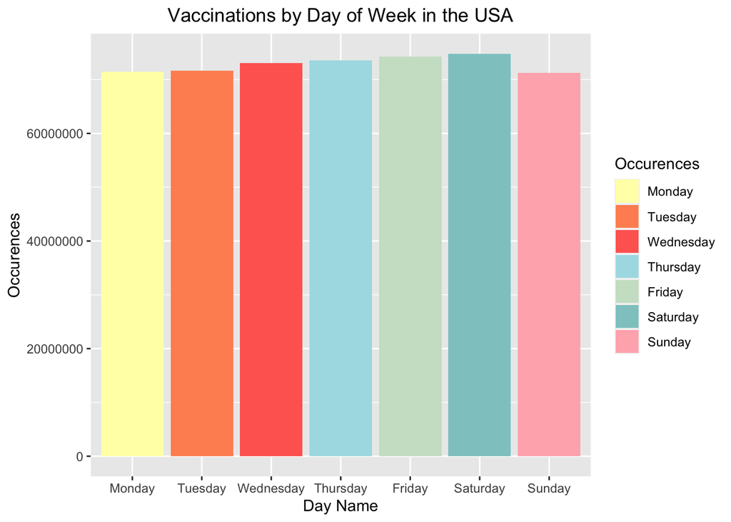

For our first chart script we chose to do it about what day is most common to get the vaccine within the USA. We chose to do it in a bar chart because it was a good way of seeing which day triumphs another. We included this as a way for the audience to see which days are the busiest according to our data set and maybe they can avoid those days to reduce waiting times and potentially save them time. It seems that most days, there is about the same amount of people getting vaccinated each day of the week but Sunday seems to be slightly less than all the others.

## Chart 2: Death Ratio in March 2021

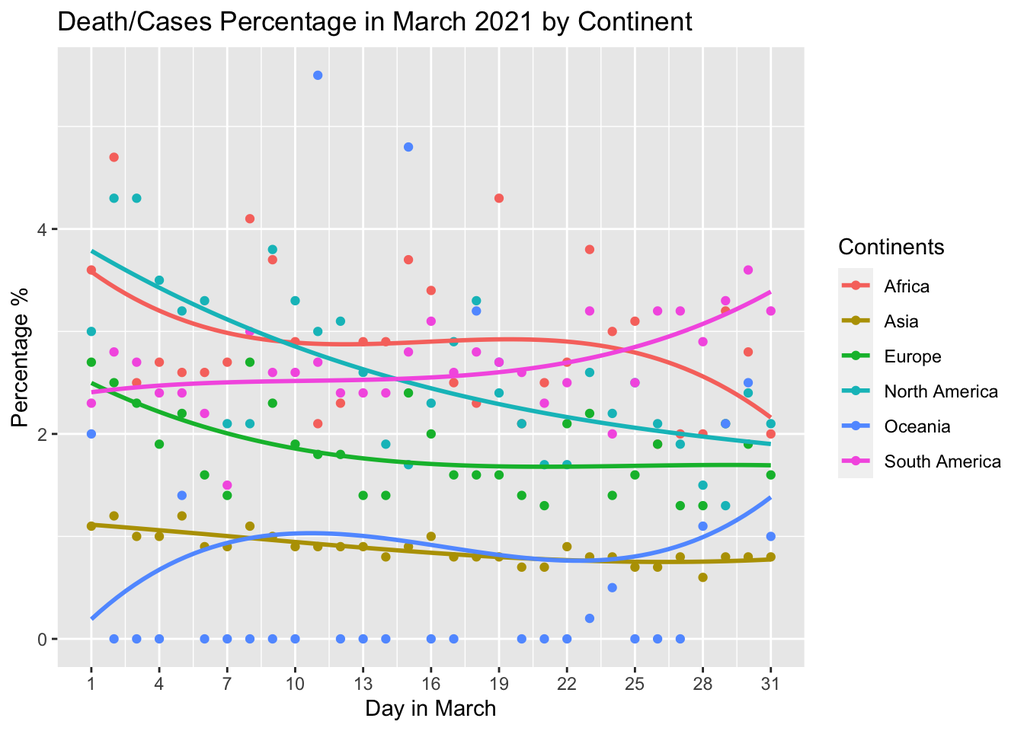

For our second chart script we wanted to analyze the Covid-19 cases/deaths ratio around the world by each continent in March 2021. With this ordinal data, we thought it would be best to represent it with a position visualization with a trend line. We organized the plot to represent the ratio of cases/death in each continent. The plot addressed the question of “Which continent had the highest cases to deaths ratio during march 2021?” And by looking at which continent had the steepest slope. Although, North America and Africa started off the highest, South America cases to death ratio increases toward the end of march to become number one on the continents.

## Chart 3: Washington Covid Cases

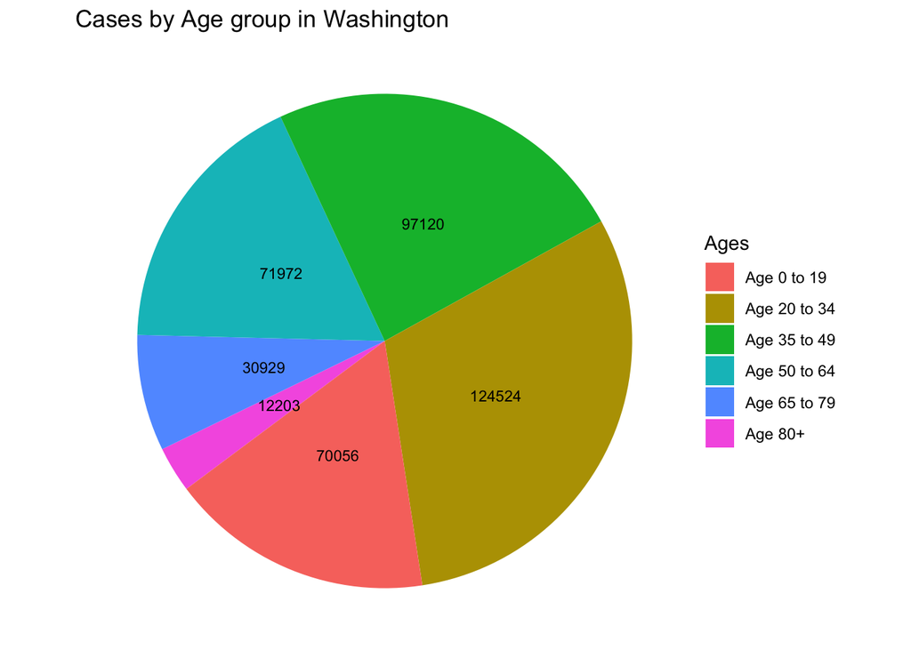

For our third chart, we decided to go with a pie chart to help display the number of Covid cases within Washington, sorted out by age group. With this chart, we are able to see the difference in the number of cases there are in Washington through different age groups. With this data, we can see that there were a lot less cases in the 65+ age group. We can ask ourselves why we think that it is like this and can conclude through this pandemic, most of the elderly people tend to stay in protecting themselves from this disease. With people in the age group of 20-49, that was more than half the cases and we can assume that their more likely to get it because of school/work that they have to do.